# Step 3 – Select Performance Indicators, Reference Points, and Assessment Methods

*What is the best way to determine the status of the fishery?*

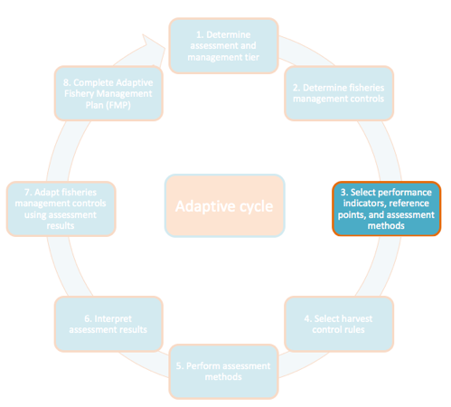

Steps 3a through 3c will guide you through selecting appropriate performance indicators, reference points, and assessment methods for your fishery.

While we provide best practices in these steps, it should be noted that performance indicators and reference points are not one-size-fits-all. They should be based on community goals for your TURF-Reserve. While setting performance indicators and reference points, consult the goals that were prioritized during the FLAGS toolkit or other goal-setting exercises. For example, if increased landings for food provision is a goal, you may wish to use landings as one of your performance indicators and upward trends in landings as a reference point. If conservation of biomass in the water for dive tourism is a goal, you may wish to use fished:unfished density ratio as one of your performance indicators and a high fished:unfished density ratio as your target reference point.

## Step 3a – Select Performance Indicators

Using Table A3. 1, select appropriate performance indicators for your fishery. Depending on the assessment and management tier your fishery falls under, there will be a number of options for the indicators you may choose to select. Whenever possible, we recommend that multiple indicators are chosen from multiple independent data streams. This will reduce the uncertainty associated with any single data stream and will paint a more complete picture of the fishery. Use the specific guidance below for your tier.

**Tier 1 – Precautionary Assessment and Management (for new FF sites with less than one year of data)**

Even though limited data will be available for a Tier 1 fishery, managers can still perform a basic qualitative fisheries assessment using local ecological knowledge about the fishery, such as the types of fishing gear that are currently used, changes in the fishing seasons that have been observed over time, and changes in species composition of landings over time. Potential performance indicators for Tier 1 are provided in *Appendix 3 – Selecting your performance indicators, reference points, and assessment methods*, along with pros, cons, and the types of species each indicator is appropriate for.

At a minimum, we recommended using the following performance indicators for Tier 1:

- At least one indicator based on qualitative fisheries characterization
- If available, at least one fishery-independent indicator based on underwater visual survey or experimental fishing

**Tier 2 – Preliminary Adaptive Assessment and Management (for FF sites with one year of data)**

Data streams in Tier 2 include those under Tier 1, as well as at least one year of fishery-dependent data that may come from a combination of Catch Reporting, Boat-intercept Surveys, and Fishery Dependent Length-composition Surveys. Potential performance indicators for Tier 2 are provided in *in Appendix 3 – Selecting your performance indicators, reference points, and assessment methods*, along with pros, cons, and the types of species each indicator is appropriate for.

At a minimum, we recommended using the following performance indicators for Tier 2:

- All indicators from Tier 1
- At least one indicator based on fishery-dependent length-composition survey

**Tier 3 – Multi-Indicator framework for Adaptive Assessment and Management (for sites with more than one year of data)**

Tier 3 sites will have a time series of data available that can be used to examine trends in multiple performance indicators in addition to information and data described under Tiers 1 and 2. Potential Tier 3 performance indicators for each available data stream type or toolkit output are provided in *Appendix 3 – Selecting your performance indicators, reference points, and assessment methods*, along with pros, cons, and the types of species each indicator is appropriate for.

At a minimum, we recommended using the following performance indicators for Tier 3:

- All indicators from Tier 2
- At least one trend-based indicator that uses a time series of landings or CPUE data

## Step 3b – Select Reference Points

During this step, select reference points for each of your chosen performance indicators. *Appendix 3 – Selecting your performance indicators, reference points, and assessment methods* offers suggestions for generic reference points from the literature that may be appropriate for each performance indicator.

For every performance indicator, select both a target reference point (TRP) as well as a limit reference point (LRP). A target reference point is a numerical value (or trend) that indicates that the performance of the fishery is at a desirable level; often management is geared towards achieving or maintaining this target. This target could be a static value chosen from the literature, or a trend in historic data (for example, a target may be that the indicator is higher than a historic running average). A limit reference point is a numerical value that indicates that the performance of the fishery is unacceptable (*e.g*., severely overfished), and that management action should be taken to improve fishery performance or population levels. Similarly, these values may come from the literature or historic data.

When selecting reference points, we recommend the following best practices:

- For reference points of length-based indicators and of fishery-independent-based indicators, we recommend using literature-based reference points
- Whenever using reference points from literature, use reference points from studies of comparable species and geographic locations.
- For CPUE- and landings-based indicators, we recommend using a time series of data to generate reference points that are based on trends or running averages.
- If local or international scientists are available for consultation, discuss reference points with them to determine if they are appropriate for your fishery and adjust values as necessary.

## Step 3c – Select Assessment Methods

During this step, select the appropriate assessment method for each of your chosen performance indicators. *Appendix 3 – Selecting your performance indicators, reference points, and assessment methods* outlines these options. Most performance indicators have only one associated assessment method; however, the performance indicator of fishing mortality has several options. Refer to *Appendix 5 – Assessment Method Descriptions* for more details about each specific assessment method including inputs, outputs, and caveats.

# Appendix 3 – Selecting Your Performance Indicators, Reference Points, and Assessment Methods

## Table A3.1: Selecting your performance indicators, reference points, and assessment methods

[output not shown]

# Appendix 5 – Assessment Method Descriptions

*Fishery Independent-Data*

*Coral Reef Thresholds*

**Inputs:**

- Estimate of total fish biomass inside and outside of NTZ

**Outputs:**

- Ratio of fish biomass outside the NTZ to the biomass inside the NTZ

**How this can be used by management:**

- Integrates many species into an ecosystem community metric
- Provides a reference direction of overall fishing mortality for all species
- Provides precautionary estimate of current status of ecosystem that supports the fishery

**Input Sensitivities:**

- Assumes no-take reserves are representative of historical, unfished biomass

**Caveats:**

- This method assumes that a fully-functioning and well-enforced NTZ has been sited appropriately with representative habitat inside and outside of the NTZ, and been in place long enough for the population living inside the NTZ to be a proxy for an un-fished population.

*Fished:Unfished Density Ratio (DR)*

**Description:** The DR uses fishery-independent data comparing ratios of density, average length density of a specific life stage (immature, mature adults, optimal size or mega-spawners), or CPUE outside to inside of no-take zones (NTZs). Babcock & MacCall (2011) provide a clear analysis of the use of density ratio (DR) assessment methods. The DR’s control rule adjusts fishing pressure according to the distance of the ratio of density outside to inside of the NTZ from a pre-specified target ratio. One drawback of the density ratio is that in situations where populations inside and outside the reserves both crash, the ratio would remain the same and indicate that fishing can commence. In the DR analysis, we modified the DR control rule to account for this dynamic. The adjustment is scaled by the overall health of the population inside the NTZ, measured as the density inside of the NTZ relative to the historic maximum density recorded in the NTZ.

**Inputs:**

- Density (or length by species) data inside and outside the NTZ (preferably collected in the same manner)
- Historical maximum density inside the NTZ

**Outputs:**

- Ratio of fish density outside the NTZ to the density inside the NTZ

**How this can be used by management:**

- Stakeholders set a management target DR
- This DR target ratio is compared to the ratio from assessment
- Effort is adjusted based on how far apart these values are

**Input Sensitivities:**

- Assumes historical maximum density inside the NTZ

**Caveats:**

- This method assumes that a fully-functioning and well-enforced NTZ has been sited appropriately with representative habitat inside and outside of the NTZ, and has been in place long enough for the population living inside the NTZ to be a proxy for an un-fished population.
  - *Implication*: May be less accurate for highly-mobile species that do not remain exclusively inside the NTZ such as snapper, tuna and mackerel.
- Time trends in this data can be difficult to interpret if densities inside the MPA are changing rapidly

*No-take zone catch-curve (Catch Curve)*

**Description:** This method utilizes length-frequency data (fish lengths) from inside and outside a NTZ to compare the slope of the right-hand side of the log transformed age-frequency histogram from inside the NTZ (an estimate of natural mortality (*M*)) to the slope of the log transformed age-frequency histogram outside the NTZ (an estimate of total mortality (*Z*)). Fishing mortality (*F*) can then be calculated based on the difference between these two (*F* = *Z* – *M*).

**Inputs:**

- Length-frequency data inside and outside NTZ (preferably collected in the same manner)
- Life history parameters (growth parameters)
- How many years the NTZ has been established and well-enforced
- Information on the sizes of fish preferred by the fishery

**Outputs**

- An estimate of fishing mortality (*F*)

**How this can be used by management :**

- Stakeholders set management target F/M based on community objectives and thresholds of risk
- Target *F*/*M* is compared with *F*/*M* from assessment
- Effort is adjusted through harvest control rules based on how far apart these values are

**Input Sensitivities:**

- Accuracy of individual fish length measurements
- Accuracy of length-at-age relationships (*Von Bertanalffy growth parameters*
- Correcting fitting of the curve (sensitive to estimates of NTZ age, preferred fish size)

**Caveats**:

- This method assumes that a NTZ has been sited appropriately, well-enforced, and been in place long enough for the population living inside the NTZ to be a proxy for an un-fished population
  - *Implication*: May be less accurate for highly-mobile species that do not remain exclusively inside the NTZ, such as snapper, tuna and mackerel
- This method depends on reliably tracking population size structure changes, thus may be less accurate with small, fast-growing species

*Fishery-Dependent Data*

*Trends Analyses*

**Description:** This method uses catch data to compare total catch, average catch, CPUE, and/or abundance between years of interests. Comparisons can be derived for sequential years, or as a running average between historical trends. Additionally, comparisons can be made across all species or by species of interest.

**Inputs:**

- Total catch for more than one year
- Catch-Per-Unit-Effort (CPUE) for more than one year
- Abundance of the catch for more than one year
- Length-frequency of the catch for more than one year

**Outputs:**

- Total catch and trends in total catch
- CPUE and trends in CPUE
- Abundance and trends in abundance
- Average length and trends in average length

**How this can be used by management:**

- Catch trends can support the interpretation of other analyses, for example of fishing morality of spawning potential ratio (SPR).
- Understanding how the trends in catch fluctuate from one year to next or in comparison to the historic trends is essential to use catch trends for management.

**Input Sensitivities:**

**Caveats:**

- This method depends on reliably tracking the total catch
- For example, raw CPUE is seldom proportional to abundance over a > whole exploitation history and an entire geographic range, because > numerous factors affect catch rates.

*Catch Curve*

**Description:** This method utilizes length-frequency data (fish lengths) to estimate the fishing mortality affecting the fished population. Total fishing mortality (*Z*) is estimated using the slope of the log transformed age-frequency histogram. Fishing mortality can then be calculated based on the difference between total fishing mortality and natural mortality (*F* = *Z* – *M*). Estimates of *M* can come from the literature.

**Inputs:**

- Length-frequency data
- Life history parameters (growth parameters)

**Outputs:**

- An estimate of fishing mortality

**How this can be used by management:**

- Stakeholders set management target *F*/*M* based on community objectives and thresholds of risk
- Target *F*/*M* is compared with *F*/*M* from assessment
- Effort is adjusted through harvest control rules based on how far apart these values are

**Input Sensitivities:**

- Accuracy of individual fish length measurements
- Accuracy of length-at-age relationships (Von Bertalanffy growth parameters)
- Correcting fitting of the curve (i.e., preferred fish size)

**Caveats:**

- This method depends on reliably tracking population size structure > changes, thus may be less accurate for small, fast-growing species

*Froese Sustainability Indicators*

**Description:** This method uses the length-frequency of the catch to estimate the distribution of life stages in the catch (Froese 2004).

**Inputs:**

- Length-frequency of the catch
- Length at maturity

**Outputs:**

- By fishing at *L<sub>opt</sub>* or the “spawn-at-least-once” principle in > conjunction with the protection of *megaspawners*, sustainability > of the fishery can be maintained.

**Input Sensitivities:**

- Accuracy of individual fish length measurements
- Accuracy of length at maturity
- Selectivity

**Caveats:**

- This method depends on reliably tracking population size structure > changes
  - Implication: May be less accurate with small, fast-growing > species

*Mean Length (L<sub>bar</sub>)*

**Description:** This method uses fishery-dependent or independent length-frequency data. *L<sub>bar</sub>* uses the minimum and maximum fished sizes, and the average length of the fish within the fished sizes from a fished population, along with growth parameters. In the Ault et al. 2005 model, *L<sub>bar</sub>* provides an estimate of fishing mortality (*F*) that can be compared to an estimate of natural mortality (*M*). Intuitively, increasing fishing pressure will often cause decreasing average length.

**Inputs:**

- Fishery-dependent or fishery-independent length-frequency data of fished population
- Life history parameters, growth parameters, and natural mortality (*M*)
- Information on the sizes of fish preferred by the fishery

**Outputs**:

- An estimate of fishing mortality (*F*)

**How this can be used by management:**

- Stakeholders set management target *F*/*M* based on community objectives and thresholds of risk
- Target *F*/*M* is compared with *F*/*M* from assessment
- Effort is adjusted based on how far apart *F*/*M* from the assessment is from the *F*/*M*

**Input Sensitivities:**

- Estimate of *M* and growth parameters
- Accuracy of individual fish length measurements

**Caveats:**

- This method depends on reliably tracking population size structure > changes
  - Implication: May be less accurate with small, fast-growing > species
- *M* is assumed to be known, which often it is not
- Assumes equilibrium
- This model is less reliable when mean fish length is very low

*Mean Weight*

**Description:** This method can use fishery-dependent or independent weight-frequency data to estimate fishing mortality (*F*) when no size structure data is available. This method requires the von Bertalanffy growth function, as well as the length-weight relationship and the natural mortality (*M*). In this method, we construct a Yield-Per-Recruit (YPR) model, which allows us to estimate the theoretical age and weight structure of the population at any size. Similar to Mean Length (*L<sub>bar</sub>*), Mean Weight provides an estimate of *F* that can be compared to an estimate of *M*. Intuitively, increasing fishing pressure will often cause decreasing average weight and/ or length.

**Inputs:**

- Fishery-dependent or fishery-independent weight-frequency data
- Life history parameters, growth parameters, natural mortality (*M*)
- Information on the sizes of fish preferred by the fishery

**Outputs**:

- An estimate of fishing mortality (*F*)

**How this can be used by management:**

- Stakeholders set management target *F*/*M* based on community objectives and thresholds of risk
- Target *F*/*M* is compared with *F*/*M* from assessment
- Effort is adjusted based on how far apart these values are

**Input Sensitivities:**

- Estimate of *M* and growth parameters
- Accuracy of individual fish weight measurements
- Accuracy of length-weight relationship

**Caveats:**

- This method depends on reliably tracking population size structure changes
  - Implication: May be less accurate for small, fast-growing species
- *M* is assumed to be known, which often it is not
- Assumes equilibrium
- This model is less reliable when mean fish weight is very low

*Bounded mean length mortality estimator*

**Description:** A modification of the Mean Length (*L<sub>bar</sub>*) method (Ehrhardt et al. 1992). Does not assume that fishing mortality has been constant over the life span of the fish being assessed, it takes into account the time since a management change, and restricts the data used for this analysis to those fish which have recruited to the fishery during this time period.

**Inputs:**

- Length-frequency of the catch, since management change
- Mean asymptotic length (cm) of the von Bertalanffy growth equation
- *L<sub>λ</sub>*, the age at *L<sub>c</sub>* (using the von Bertalanffy equation) and adding the number of years since a known harvest rate policy change, then converting back to length
- *L<sub>bar</sub>* is the mean length of fish between *L<sub>c</sub>* and *L<sub>λ</sub>*.

**Outputs:**

- An estimate of fishing mortality (*F*)

**How this can be used by management:**

- Stakeholders set management target *F*/*M* based on community objectives and thresholds of risk
- Target *F*/*M* is compared with *F*/*M* from assessment
- Effort is adjusted based on how far apart these values are

**Input Sensitivities:**

- Estimate of *M* and growth parameters
- Accuracy of individual fish length measurements

**Caveats:**

- This method depends on reliably tracking population size structure changes
  - Implication: May be less accurate for small, fast-growing species
- *M* is assumed to be known, which often it is not
- Assumes equilibrium
- This model is less reliable when mean fish length is very low

*Length-based Spawning Potential Ratio (SBSPR)*

**Description:** Length-based Pawning Potential Ratio (SBSPR) method uses length-frequency data from a fished population to calculate the spawning potential ratio (SPR) of a fishery (Hordyk et al. 2014). This method is based on the concept that the equilibrium unfished size structure of a population depends on the average maximum size attained and the ratio of the rate of natural mortality (*M*) to the individual growth rate (*K*; Prince et al. 2014). SPR is a measure of current egg production relative to maximum possible production at un-fished levels. Un-fished egg production is estimated using the natural mortality (*M*), Von Bertanaffy (*VBK*) growth parameters, age at first maturity, and fecundity at age. The fished SPR is calculated using the same parameters, along with estimates of the fishing mortality rate (*F*), and the sizes of fish selected by the fishery. By comparing the estimated current SPR with a target SPR defined by stakeholders, a harvest control rule can be used to adjust fisheries management controls accordingly.

**Inputs**:

- Length-frequency data from a fished population
- Gear selectivity
- Life history parameters (fecundity, *VBK* parameters, natural mortality, age-at-maturity, length at age relationships)

**Outputs:**

- SPR of target species

**How this can be used by management:**

- Stakeholders set management target SPR
- Target SPR is compared to SPR from assessment
- Effort is adjusted based on how far apart these values are

**Input Sensitivities:**

- Accuracy of individual fish length measurements
- Representativeness of the length data
- Accuracy of life history information, particularly growth and maturity parameters

**Caveats:**

- This method is dependent on reliably tracking changes in population size structure
  - *Implication*: May be less accurate for small, fast-growing species, such as surgeonfish, scad and spinefoot rabbit fish
- Assumes the fishery is equilibrium and that conditions are relatively stable (environmental conditions, fishing pressure, stock status, etc.)
- This method is less accurate if fishing pressures has been changing dramatically year to year
- This method is less effective for species with highly variable recruitment (addition of juveniles to the population) such as lobster